# Practical Lab - 3

## *Univariate Linear Regression*

#### Getting the Data

Data Sourcecode link - [Kaggle_california_housingprices_dataset](https://www.kaggle.com/datasets/camnugent/california-housing-prices)

#### Import the Packages

```python
import pandas as pd
import seaborn as sns
import matplotlib.pyplot as plt
from sklearn.linear_model import LinearRegression
from sklearn.metrics import mean_squared_error, mean_absolute_error
```

```python
housing = pd.read_csv('data/housing.csv')
```

### **Exploratory Data Analysis (EDA)**

```python
housing.describe()
```

|  | longitude | latitude | housing_median_age | total_rooms | total_bedrooms | population | households | median_income | median_house_value |
| --- | --- | --- | --- | --- | --- | --- | --- | --- | --- |
| count | 20640.000000 | 20640.000000 | 20640.000000 | 20640.000000 | 20433.000000 | 20640.000000 | 20640.000000 | 20640.000000 | 20640.000000 |
| mean | -119.569704 | 35.631861 | 28.639486 | 2635.763081 | 537.870553 | 1425.476744 | 499.539680 | 3.870671 | 206855.816909 |
| std | 2.003532 | 2.135952 | 12.585558 | 2181.615252 | 421.385070 | 1132.462122 | 382.329753 | 1.899822 | 115395.615874 |
| min | -124.350000 | 32.540000 | 1.000000 | 2.000000 | 1.000000 | 3.000000 | 1.000000 | 0.499900 | 14999.000000 |
| 25% | -121.800000 | 33.930000 | 18.000000 | 1447.750000 | 296.000000 | 787.000000 | 280.000000 | 2.563400 | 119600.000000 |
| 50% | -118.490000 | 34.260000 | 29.000000 | 2127.000000 | 435.000000 | 1166.000000 | 409.000000 | 3.534800 | 179700.000000 |
| 75% | -118.010000 | 37.710000 | 37.000000 | 3148.000000 | 647.000000 | 1725.000000 | 605.000000 | 4.743250 | 264725.000000 |
| max | -114.310000 | 41.950000 | 52.000000 | 39320.000000 | 6445.000000 | 35682.000000 | 6082.000000 | 15.000100 | 500001.000000 |

### **Explore statistics**

Accordind to the given Dataset, the values for the given varaibles is:

[output not shown]

- For Medien income by observed value, the presence of outliers or skewed data could affect the performance of linear regression models.
- For the Population,that the minimum population is very low and may affect the analysis.

### **Seaborn Scatter Plots**

Scatter Plot between Median Income and Median House Value

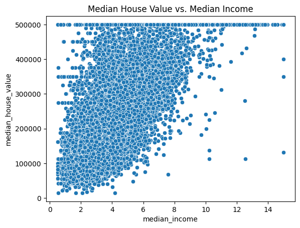

```python
sns.scatterplot(x='median_income', y='median_house_value', data=housing)
plt.title('Median House Value vs. Median Income')
```

Insights: The data shows that as people's median income increases, the median house value tends to go up in a straight line. While there are a few points that don't fit this pattern.

Scatter Plot between Population and Median House Value

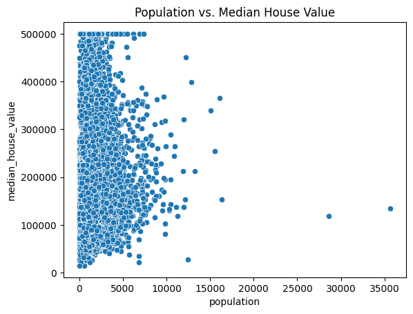

```python
sns.scatterplot(x='population', y='median_house_value', data=housing)
plt.title('Population vs. Median House Value')
```

Scatter Plot between Number of Households and Median House Value

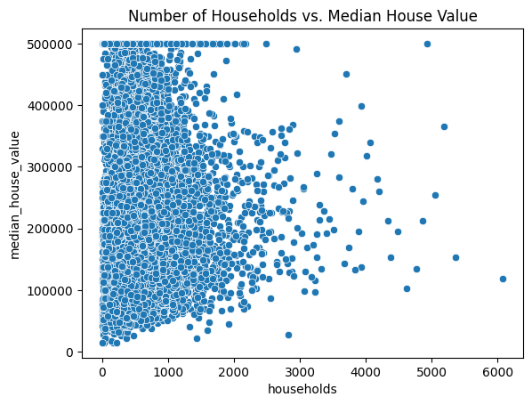

```python
sns.scatterplot(x='households', y='median_house_value', data=housing)
plt.title('Number of Households vs. Median House Value')
```

### **Linear Regression**

Define and Train the model

```python
# fit between median_income and median_house_value
model1 = LinearRegression().fit(housing[['median_income']], housing['median_house_value'])

# fit between population and median_house_value
model2 = LinearRegression().fit(housing[['population']], housing['median_house_value'])

# fit between households and median_house_value
model3 = LinearRegression().fit(housing[['households']], housing['median_house_value'])
```

**Evaluate the Model**

Summary of the model

```python
pred_1 = model1.predict(housing[['median_income']])
mse_1 = mean_squared_error(housing['median_house_value'], pred_1)
mae_1 = mean_absolute_error(housing['median_house_value'], pred_1)
intercept_1 = model1.intercept_
slope_1 = model1.coef_

pred_2 = model2.predict(housing[['population']])
mse_2 = mean_squared_error(housing['median_house_value'], pred_2)
mae_2 = mean_absolute_error(housing['median_house_value'], pred_2)
intercept_2 = model2.intercept_
slope_2 = model2.coef_

pred_3 = model3.predict(housing[['households']])
mse_3 = mean_squared_error(housing['median_house_value'], pred_3)
mae_3 = mean_absolute_error(housing['median_house_value'], pred_3)
intercept_3 = model3.intercept_
slope_3 = model3.coef_
```

```python
table = pd.DataFrame({
    'Model': ['Median House Value vs. Median Income', 'Population vs. Median House Value', 'Number of Households vs. Median House Value'],
    'Intercept': [intercept_1, intercept_2, intercept_3],
    'Slope': [model1.coef_, model2.coef_, model3.coef_],
    'Mean Squared Error (MSE)': [mse_1, mse_2, mse_3],
    'Mean Absolute Error (MAE)': [mae_1, mae_2, mae_3]
})

print(table)
```

```
                                         Model      Intercept
0         Median House Value vs. Median Income   45085.576703  \
1            Population vs. Median House Value  210436.262076
2  Number of Households vs. Median House Value  196928.577162

                  Slope  Mean Squared Error (MSE)  Mean Absolute Error (MAE)
0  [41793.849201896286]              7.011312e+09               62625.933791
1  [-2.511752774615085]              1.330741e+10               91153.820095
2  [19.872775155643875]              1.325778e+10               90802.743243
```

**Resulting Plots**

Model1 - Plot between Median House Value vs Median Income

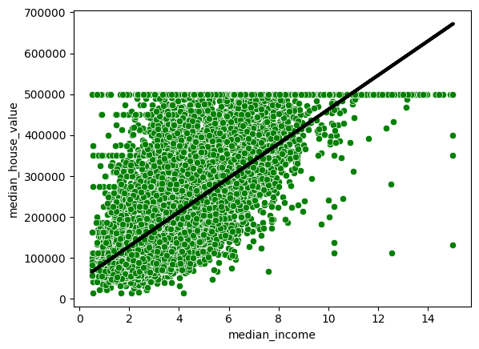

```python
sns.scatterplot(x="median_income", y="median_house_value", data=housing, color="green")
plt.plot(housing[["median_income"]], model1.predict(housing[["median_income"]]), color="black", linewidth=3)
plt.show()
```

Model2 - Plot between Median House Value vs Population

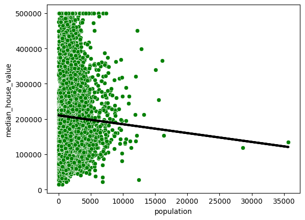

```python
sns.scatterplot(x="population", y="median_house_value", data=housing, color="green")
plt.plot(housing[["population"]], model2.predict(housing[["population"]]), color="black", linewidth=3)
plt.show()
```

Model3 - Plot between Median House Value vs Number of Households

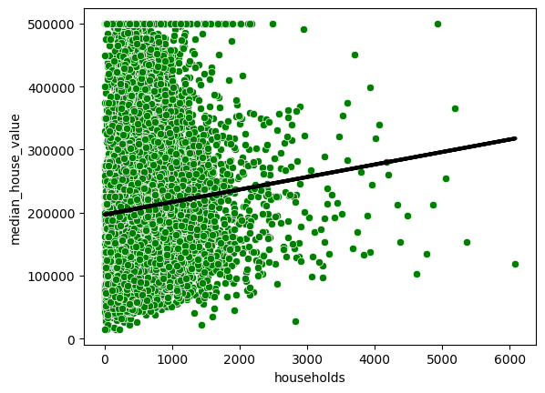

```python
sns.scatterplot(x="households", y="median_house_value", data=housing, color="green")
plt.plot(housing[["households"]], model3.predict(housing[["households"]]), color="black", linewidth=3)
plt.show()
```

### **Conclusion**

The insight obtained from the comparison and evaluation of the three models is that, among the variables considered (median income, population, and number of households), median income emerges as the most reliable predictor of median house value. This conclusion is drawn from the lower Mean Squared Error (MSE) and Mean Absolute Error (MAE) values observed in Model 1, indicating a better fit to the data compared to the models based on population and number of households. The positive slope in Model 1 suggests that as median income increases, median house value tends to increase, reinforcing the predictive strength of this variable. This insight underscores the importance of considering the impact of different predictor variables when building regression models and highlights the superior predictive power of median income in this particular analysis.